# Interactions with GPs

GK

2023-05-12

# An SPDEs approach to model the synergy between temperature and air-pollution on health

## Simulation

We can create 3-5 simulation scenarios based on real-life examples. A recent paper by the MCMC group used some sort of 2d splines to model interactions for ~500 cities and 2 health outcomes (respiratory and cardiovascular mortality). What we could do is simulate N scenarios based on the surfaces of that paper and fit an spde and the regular interaction model and compare. We will use the Italian dataset as the basis of the interaction. The linear effect of PM10, the non-linear effect of temperature, the effect of national holidays and the spatiotemporal trends could be either determined by the model without the interaction or using the literature.

We can have 2 subsequent papers based on this: 1. An applied one where we do this for COPD 2. An extension of this approach is DLNMs in space (3-way interaction)

## Description

I will develop 3 main interaction models:

- Regular
- Linear
- Flexible To model the synergistic effect of PM$_{10}$ and temperature on all cause-mortality in Italy.

```r
dat <- readRDS("ItalyData")
shp <- readRDS("shp")
W.nb <- spdep::poly2nb(shp)
spdep::nb2INLA("W.adj", W.nb)
theta <- NULL

dat$temp_id <- inla.group(dat$temperature_lag0_3, method = "cut", n = 50)
dat$pm_id <- inla.group(dat$pm10_lag0_3, method = "cut", n = 50)
dat$datid <- as.numeric(as.factor(dat$date))
dat$year_cont <-  dat$year - min(dat$year) + 1
dat$space_id <- as.numeric(as.factor(dat$SIGLA))

hyper.iid <- list(theta=list(prior="pc.prec", param=c(0.1, 0.01)))
hyper.bym <- list(theta1=list("PCprior", c(1, 0.01)), theta2 = list("PCprior", c(0.5, 0.5)))
control.family <- inla.set.control.family.default()
```

## No interaction model

### INLA model

```r
form_nointeraction =
  deaths ~
  offset(log(expected)) +
  as.factor(hol) +
  year_cont +
  f(datid, model = "rw2", hyper = hyper.iid, constr = TRUE, scale.model = TRUE) +
  f(space_id, model = "bym2", graph = "W.adj", scale.model = TRUE, hyper = hyper.bym, constr = TRUE) +
  f(temp_id, model = "rw2", hyper = hyper.iid, constr = TRUE, scale.model = TRUE) +
  pm10_lag0_3
  # f(pm_id, model = "rw2", hyper = hyper.iid, constr = TRUE, scale.model = TRUE) this is the non linear alternative which justifies the linearity assumption

inla(form_nointeraction,
     data = dat,
     family = "Poisson",
     control.family = control.family,
     verbose = FALSE,
     num.threads = 2,
     control.compute = list(config = TRUE),
     control.predictor = list(link=1),
     control.mode = list(theta=theta, restart=TRUE)
     ) -> mod1
```

The effect is 0.2% increase in the mortality risk for every unit increase in the PM10 ### Extract results

```r
shp$ID <- as.numeric(as.factor(shp$SIGLA))
shp <- left_join(shp, mod1$summary.random$space_id)
```

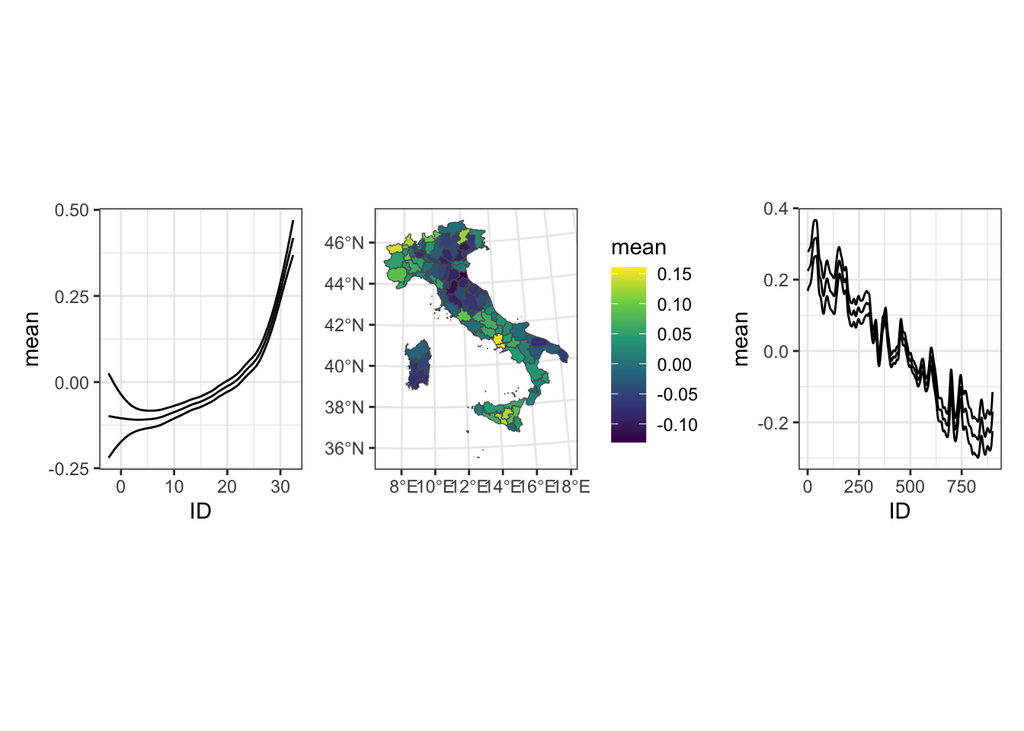

```r
ggplot(data = mod1$summary.random$temp_id) +
  geom_line(aes(x=ID, y=mean)) +
  geom_line(aes(x=ID, y=`0.025quant`)) +
  geom_line(aes(x=ID, y=`0.975quant`)) + theme_bw()|

ggplot(data = shp) +
  geom_sf(aes(fill = mean)) +
  scale_fill_viridis_c() +
  theme_bw()|

ggplot(data = mod1$summary.random$datid) +
  geom_line(aes(x=ID, y=mean)) +
  geom_line(aes(x=ID, y=`0.025quant`)) +
  geom_line(aes(x=ID, y=`0.975quant`)) + theme_bw()
```

```r
shp <- shp[,1:6]

summary(mod1)
```

```
##
## Call:
##    c("inla.core(formula = formula, family = family, contrasts = contrasts,
##    ", " data = data, quantiles = quantiles, E = E, offset = offset, ", "
##    scale = scale, weights = weights, Ntrials = Ntrials, strata = strata,
##    ", " lp.scale = lp.scale, link.covariates = link.covariates, verbose =
##    verbose, ", " lincomb = lincomb, selection = selection, control.compute
##    = control.compute, ", " control.predictor = control.predictor,
##    control.family = control.family, ", " control.inla = control.inla,
##    control.fixed = control.fixed, ", " control.mode = control.mode,
##    control.expert = control.expert, ", " control.hazard = control.hazard,
##    control.lincomb = control.lincomb, ", " control.update =
##    control.update, control.lp.scale = control.lp.scale, ", "
##    control.pardiso = control.pardiso, only.hyperparam = only.hyperparam,
##    ", " inla.call = inla.call, inla.arg = inla.arg, num.threads =
##    num.threads, ", " blas.num.threads = blas.num.threads, keep = keep,
##    working.directory = working.directory, ", " silent = silent, inla.mode
##    = inla.mode, safe = FALSE, debug = debug, ", " .parent.frame =
##    .parent.frame)")
## Time used:
##     Pre = 10.7, Running = 17.5, Post = 1.1, Total = 29.3
## Fixed effects:
##                   mean    sd 0.025quant 0.5quant 0.975quant   mode kld
## (Intercept)     -0.402 0.036     -0.474   -0.402     -0.331 -0.402   0
## as.factor(hol)1 -0.019 0.008     -0.034   -0.019     -0.004 -0.019   0
## year_cont        0.080 0.010      0.061    0.080      0.099  0.080   0
## pm10_lag0_3      0.002 0.000      0.002    0.002      0.002  0.002   0
##
## Random effects:
##   Name     Model
##     datid RW2 model
##    space_id BYM2 model
##    temp_id RW2 model
##
## Model hyperparameters:
##                           mean      sd 0.025quant 0.5quant 0.975quant    mode
## Precision for datid      0.310   0.055      0.215    0.306      0.429   0.298
## Precision for space_id 232.013  33.754    171.471  230.051    304.196 226.783
## Phi for space_id         0.091   0.082      0.006    0.066      0.312   0.016
## Precision for temp_id  330.703 144.039    129.007  304.688    685.385 257.041
##
## Marginal log-Likelihood:  -263264.42
##  is computed
## Posterior summaries for the linear predictor and the fitted values are computed
## (Posterior marginals needs also 'control.compute=list(return.marginals.predictor=TRUE)')
```

## Regular interaction model

### INLA model

```r
dat$pol_temp <- scale(dat$pm10_lag0_3*dat$temperature_lag0_3)
sd(dat$pm10_lag0_3*dat$temperature_lag0_3)
```

```
## [1] 201.03
```

```r
form_regint =
  deaths ~
  offset(log(expected)) +
  as.factor(hol) +
  year_cont +
  f(datid, model = "rw2", hyper = hyper.iid, constr = TRUE, scale.model = TRUE) +
  f(space_id, model = "bym2", graph = "W.adj", scale.model = TRUE, hyper = hyper.bym, constr = TRUE) +
  f(temp_id, model = "rw2", hyper = hyper.iid, constr = TRUE, scale.model = TRUE) +
  pm10_lag0_3 +
  pol_temp

inla(form_regint,
     data = dat,
     family = "Poisson",
     control.family = control.family,
     verbose = FALSE,
     num.threads = 2,
     control.compute = list(config = TRUE),
     control.predictor = list(link=1),
     control.mode = list(theta=theta, restart=TRUE)
     ) -> mod2
```

### Extract results

```r
shp$ID <- as.numeric(as.factor(shp$SIGLA))
shp <- left_join(shp, mod2$summary.random$space_id)
```

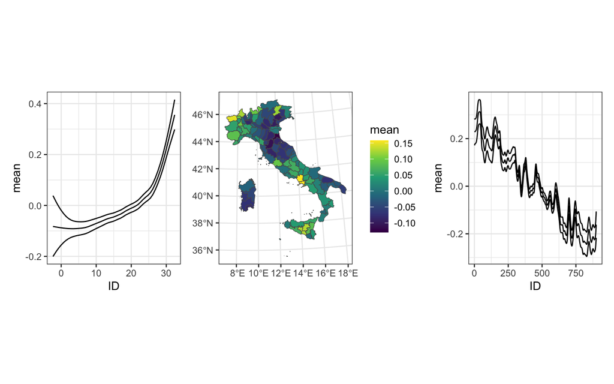

```r
ggplot(data = mod2$summary.random$temp_id) +
  geom_line(aes(x=ID, y=mean)) +
  geom_line(aes(x=ID, y=`0.025quant`)) +
  geom_line(aes(x=ID, y=`0.975quant`)) + theme_bw()|

ggplot(data = shp) +
  geom_sf(aes(fill = mean)) +
  scale_fill_viridis_c() +
  theme_bw()|

ggplot(data = mod2$summary.random$datid) +
  geom_line(aes(x=ID, y=mean)) +
  geom_line(aes(x=ID, y=`0.025quant`)) +
  geom_line(aes(x=ID, y=`0.975quant`)) + theme_bw()
```

```r
shp <- shp[,1:6]

summary(mod2)
```

```
##
## Call:
##    c("inla.core(formula = formula, family = family, contrasts = contrasts,
##    ", " data = data, quantiles = quantiles, E = E, offset = offset, ", "
##    scale = scale, weights = weights, Ntrials = Ntrials, strata = strata,
##    ", " lp.scale = lp.scale, link.covariates = link.covariates, verbose =
##    verbose, ", " lincomb = lincomb, selection = selection, control.compute
##    = control.compute, ", " control.predictor = control.predictor,
##    control.family = control.family, ", " control.inla = control.inla,
##    control.fixed = control.fixed, ", " control.mode = control.mode,
##    control.expert = control.expert, ", " control.hazard = control.hazard,
##    control.lincomb = control.lincomb, ", " control.update =
##    control.update, control.lp.scale = control.lp.scale, ", "
##    control.pardiso = control.pardiso, only.hyperparam = only.hyperparam,
##    ", " inla.call = inla.call, inla.arg = inla.arg, num.threads =
##    num.threads, ", " blas.num.threads = blas.num.threads, keep = keep,
##    working.directory = working.directory, ", " silent = silent, inla.mode
##    = inla.mode, safe = FALSE, debug = debug, ", " .parent.frame =
##    .parent.frame)")
## Time used:
##     Pre = 9.1, Running = 13.3, Post = 0.661, Total = 23.1
## Fixed effects:
##                   mean    sd 0.025quant 0.5quant 0.975quant   mode kld
## (Intercept)     -0.339 0.040     -0.418   -0.339     -0.261 -0.339   0
## as.factor(hol)1 -0.019 0.008     -0.034   -0.019     -0.004 -0.019   0
## year_cont        0.078 0.010      0.059    0.078      0.098  0.078   0
## pm10_lag0_3     -0.001 0.001     -0.002   -0.001      0.001 -0.001   0
## pol_temp         0.028 0.007      0.014    0.028      0.042  0.028   0
##
## Random effects:
##   Name     Model
##     datid RW2 model
##    space_id BYM2 model
##    temp_id RW2 model
##
## Model hyperparameters:
##                           mean      sd 0.025quant 0.5quant 0.975quant    mode
## Precision for datid      0.295   0.052      0.206    0.291      0.409   0.283
## Precision for space_id 234.895  33.700    174.433  232.939    306.939 229.642
## Phi for space_id         0.072   0.076      0.004    0.046      0.288   0.011
## Precision for temp_id  379.454 174.531    142.526  345.711    814.745 285.708
##
## Marginal log-Likelihood:  -263264.93
##  is computed
## Posterior summaries for the linear predictor and the fitted values are computed
## (Posterior marginals needs also 'control.compute=list(return.marginals.predictor=TRUE)')
```

### Interaction plots

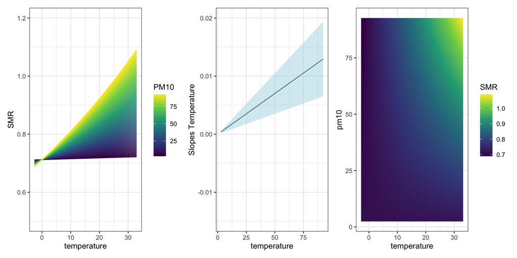

```r
N <- 100

# mod2$summary.fixed$`0.5quant`[5] # the slope of the scaled interaction. This can be multiplied with the scaled PM and give us different slopes
pm_grid <- seq(from = min(dat$pm10_lag0_3), to = max(dat$pm10_lag0_3), length.out = N)
temp_grid <- seq(from = min(dat$temperature_lag0_3), to = max(dat$temperature_lag0_3), length.out = N)

line_temp <- list()
for(i in 1:N){
  line_temp[[i]] <- mod2$summary.fixed$`0.5quant`[1] + pm_grid[i]*temp_grid*mod2$summary.fixed$`0.5quant`[5]/sd(dat$pm10_lag0_3*dat$temperature_lag0_3)
}

line_temp_dat <- data.frame(
  RR = exp(do.call(c, line_temp)),
  temperature = rep(temp_grid, times = N),
  PM10 = rep(pm_grid, each = N)
)

ggplot() + geom_line(data = line_temp_dat, aes(x = temperature, y = RR, group = PM10, col = PM10)) + theme_bw() +
  scale_color_viridis_c() + ylab("SMR") + ylim(c(0.5, 1.2))-> p1

slopes_temp <-
  data.frame(
    slope = pm_grid*mod2$summary.fixed$`0.5quant`[5]/sd(dat$pm10_lag0_3*dat$temperature_lag0_3),
    temperature = pm_grid,
    highslope = pm_grid*mod2$summary.fixed$`0.975quant`[5]/sd(dat$pm10_lag0_3*dat$temperature_lag0_3),
    lowsplope =   pm_grid*mod2$summary.fixed$`0.025quant`[5]/sd(dat$pm10_lag0_3*dat$temperature_lag0_3)
  )

ggplot() +
#  geom_point(data = slopes_temp, aes(x = temperature, y = slope), size = 0.6) +
  geom_line(data = slopes_temp, aes(x = temperature, y = slope)) +
  # geom_line(data = slopes_temp, aes(x = temperature, y = lowsplope)) +
  # geom_line(data = slopes_temp, aes(x = temperature, y = highslope)) +
  geom_ribbon(data=slopes_temp, aes(x=temperature,ymin=lowsplope,ymax=highslope), fill = "lightblue",alpha = 0.5) + ylab("Slopes Temperature") + ylim(c(-0.015, 0.020)) +
  theme_bw() -> p2

expand.grid(
  pm10 = pm_grid,
  temperature = temp_grid
) -> gridint
gridint$SMR <- exp(gridint$pm10*gridint$temperature*mod2$summary.fixed$`0.5quant`[5]/sd(dat$pm10_lag0_3*dat$temperature_lag0_3) +
                     mod2$summary.fixed$`0.5quant`[1])

ggplot() + geom_tile(data = gridint, aes(x = temperature, y = pm10, fill = SMR)) + theme_bw() +
  scale_fill_viridis_c() -> p3


P1 <- p1|p2|p3
P1
```

```r
boxcomp_regint <- gridint$SMR
```

## Linear interaction model

### INLA model

```r
cut_var <- 30
dat$temp_id_int <- inla.group(dat$temperature_lag0_3, method = "cut", n = cut_var)

form_linear_int =
  deaths ~
  offset(log(expected)) +
  as.factor(hol) +
  year_cont +
  f(datid, model = "rw2", hyper = hyper.iid, constr = TRUE, scale.model = TRUE) +
  f(space_id, model = "bym2", graph = "W.adj", scale.model = TRUE, hyper = hyper.bym, constr = TRUE) +
  f(temp_id, model = "rw2", hyper = hyper.iid, constr = TRUE, scale.model = TRUE) +
  pm10_lag0_3 +
  f(temp_id_int, pm10_lag0_3, model = "rw2", hyper = hyper.iid, constr = TRUE)


inla(form_linear_int,
     data = dat,
     family = "Poisson",
     control.family = control.family,
     verbose = FALSE,
     num.threads = 2,
     control.compute = list(config = TRUE),
     control.predictor = list(link=1),
     control.mode = list(theta=theta, restart=TRUE)
     ) -> mod4
```

### Extract results

```r
shp$ID <- as.numeric(as.factor(shp$SIGLA))
shp <- left_join(shp, mod4$summary.random$space_id)
```

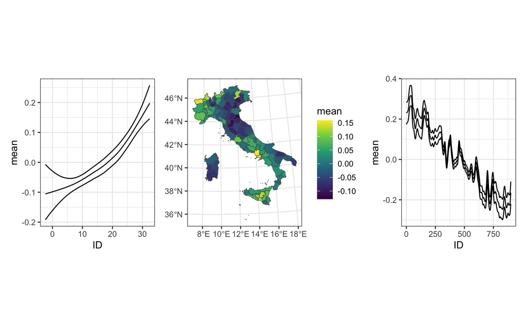

```r
ggplot(data = mod4$summary.random$temp_id) +
  geom_line(aes(x=ID, y=mean)) +
  geom_line(aes(x=ID, y=`0.025quant`)) +
  geom_line(aes(x=ID, y=`0.975quant`)) + theme_bw()|

ggplot(data = shp) +
  geom_sf(aes(fill = mean)) +
  scale_fill_viridis_c() +
  theme_bw()|

ggplot(data = mod4$summary.random$datid) +
  geom_line(aes(x=ID, y=mean)) +
  geom_line(aes(x=ID, y=`0.025quant`)) +
  geom_line(aes(x=ID, y=`0.975quant`)) + theme_bw()
```

```r
shp <- shp[,1:6]
```

```r
summary(mod4)
```

```
##
## Call:
##    c("inla.core(formula = formula, family = family, contrasts = contrasts,
##    ", " data = data, quantiles = quantiles, E = E, offset = offset, ", "
##    scale = scale, weights = weights, Ntrials = Ntrials, strata = strata,
##    ", " lp.scale = lp.scale, link.covariates = link.covariates, verbose =
##    verbose, ", " lincomb = lincomb, selection = selection, control.compute
##    = control.compute, ", " control.predictor = control.predictor,
##    control.family = control.family, ", " control.inla = control.inla,
##    control.fixed = control.fixed, ", " control.mode = control.mode,
##    control.expert = control.expert, ", " control.hazard = control.hazard,
##    control.lincomb = control.lincomb, ", " control.update =
##    control.update, control.lp.scale = control.lp.scale, ", "
##    control.pardiso = control.pardiso, only.hyperparam = only.hyperparam,
##    ", " inla.call = inla.call, inla.arg = inla.arg, num.threads =
##    num.threads, ", " blas.num.threads = blas.num.threads, keep = keep,
##    working.directory = working.directory, ", " silent = silent, inla.mode
##    = inla.mode, safe = FALSE, debug = debug, ", " .parent.frame =
##    .parent.frame)")
## Time used:
##     Pre = 9.28, Running = 19.8, Post = 0.741, Total = 29.8
## Fixed effects:
##                   mean    sd 0.025quant 0.5quant 0.975quant   mode kld
## (Intercept)     -0.422 0.038     -0.495   -0.422     -0.348 -0.422   0
## as.factor(hol)1 -0.019 0.008     -0.034   -0.019     -0.004 -0.019   0
## year_cont        0.079 0.010      0.060    0.079      0.099  0.079   0
## pm10_lag0_3      0.002 0.001      0.000    0.002      0.004  0.002   0
##
## Random effects:
##   Name     Model
##     datid RW2 model
##    space_id BYM2 model
##    temp_id RW2 model
##    temp_id_int RW2 model
##
## Model hyperparameters:
##                               mean       sd 0.025quant 0.5quant 0.975quant
## Precision for datid       3.04e-01 5.50e-02   2.14e-01 2.98e-01   4.29e-01
## Precision for space_id    2.32e+02 3.38e+01   1.73e+02 2.30e+02   3.05e+02
## Phi for space_id          8.30e-02 7.90e-02   5.00e-03 5.80e-02   3.02e-01
## Precision for temp_id     5.21e+03 5.50e+03   6.00e+02 3.59e+03   1.97e+04
## Precision for temp_id_int 1.94e+07 1.14e+07   5.30e+06 1.69e+07   4.86e+07
##                               mode
## Precision for datid       2.85e-01
## Precision for space_id    2.26e+02
## Phi for space_id          1.40e-02
## Precision for temp_id     1.60e+03
## Precision for temp_id_int 1.24e+07
##
## Marginal log-Likelihood:  -263252.90
##  is computed
## Posterior summaries for the linear predictor and the fitted values are computed
## (Posterior marginals needs also 'control.compute=list(return.marginals.predictor=TRUE)')
```

The above needs to be done more properly but the idea is there.

### Interaction plots

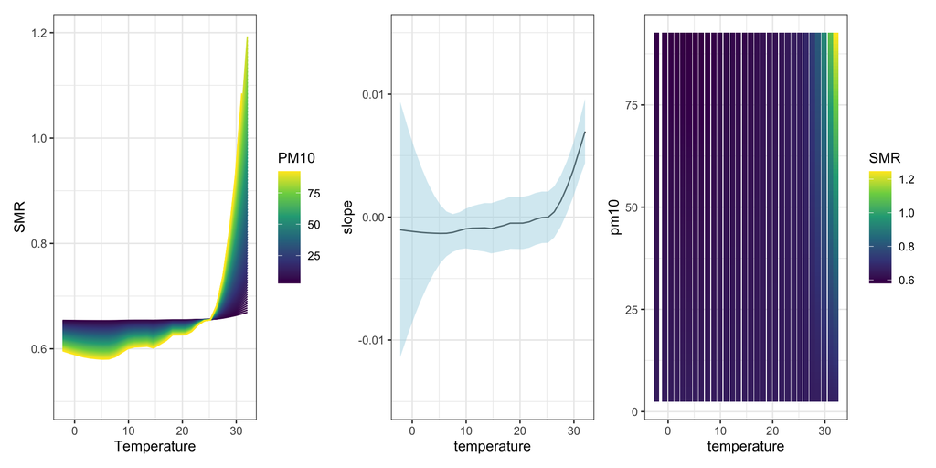

```r
N <- dat$temp_id_int %>% unique() %>% length()

line_temp <- list()
line_temp_low <- list()
line_temp_high <- list()

for(i in 1:N){
  line_temp[[i]] <- mod4$summary.fixed$`0.5quant`[1] + mod4$summary.random$temp_id_int$`0.5quant`[i]*pm_grid

  line_temp_high[[i]] <- mod4$summary.fixed$`0.5quant`[1] + mod4$summary.random$temp_id_int$`0.975quant`[i]*pm_grid

    line_temp_low[[i]] <- mod4$summary.fixed$`0.5quant`[1] + mod4$summary.random$temp_id_int$`0.025quant`[i]*pm_grid
}

line_temp_dat <- data.frame(
  RR = exp(do.call(c, line_temp)),
  RR_low = exp(do.call(c, line_temp_low)),
  RR_high = exp(do.call(c, line_temp_high)),
  PM10 = rep(pm_grid, times = N),
  Temperature = rep(mod4$summary.random$temp_id_int$ID, each = 100)
)



ggplot() + geom_line(data = line_temp_dat,
                     aes(x = Temperature, y = RR, group = PM10, col = PM10)) +
  scale_color_viridis_c() +
  scale_fill_viridis_c() +
  ylab("SMR") +
    theme_bw() + ylim(c(0.5, 1.2)) -> p1


slopes_temp <-
  data.frame(
    slope =
      mod4$summary.random$temp_id_int$`0.5quant`,
    temperature = mod4$summary.random$temp_id_int$ID,
    highslope =
      mod4$summary.random$temp_id_int$`0.975quant`,
    lowsplope =
      mod4$summary.random$temp_id_int$`0.025quant`
  )

ggplot() +
#  geom_point(data = slopes_temp, aes(x = temperature, y = slope), size = 0.6) +
  geom_line(data = slopes_temp, aes(x = temperature, y = slope)) +
  # geom_line(data = slopes_temp, aes(x = temperature, y = lowsplope)) +
  # geom_line(data = slopes_temp, aes(x = temperature, y = highslope)) +
  geom_ribbon(data=slopes_temp, aes(x=temperature,ymin=lowsplope,ymax=highslope), fill = "lightblue",alpha = 0.5) + ylim(c(-0.015, 0.015)) +
  theme_bw() -> p2

expand.grid(
  pm10 = pm_grid,
  temperature = mod4$summary.random$temp_id_int$ID
) -> gridint

gridint <- left_join(gridint, mod4$summary.random$temp_id_int, by = c("temperature" = "ID"))
gridint$SMR <- exp(gridint$pm10*gridint$`0.5quant` +
                     mod4$summary.fixed$`0.5quant`[1])

ggplot() + geom_tile(data = gridint, aes(x = temperature, y = pm10, fill = SMR)) + theme_bw() +
  scale_fill_viridis_c() -> p3


P3 <- p1|p2|p3
P3
```

```r
boxcomp_linint <- gridint$SMR
```

## SPDE interaction model

### Prepare data

```r
cut_var <- 30
dat$temp_id_int <- inla.group(dat$temperature_lag0_3, method = "cut", n = cut_var)
dat$pm_id_int <- inla.group(dat$pm10_lag0_3, method = "cut", n = cut_var)

dat$interaction_id <- paste0(dat$temp_id_int, dat$pm_id_int)
dat$interaction_id <- as.numeric(as.factor(dat$interaction_id))
max(dat$interaction_id) # this is not cut_var^2 as there is no data in all pixels but this is fine for the iid
```

```
## [1] 411
```

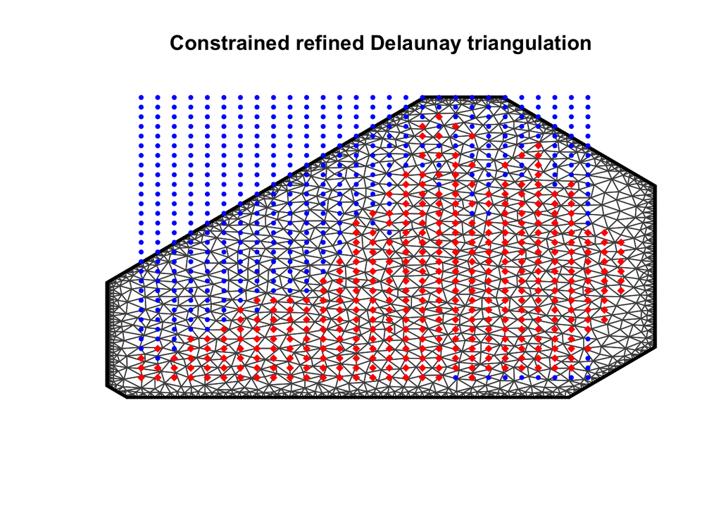

```r
dat$temp_id2 <- dat$temp_id

dat$pm_id_factor <- dat$pm_id_int %>% as.factor() %>% as.numeric()
dat$temp_id_factor <- dat$temp_id_int %>% as.factor() %>% as.numeric()

expand.grid(
  x = unique(dat$pm_id_factor),
  y = unique(dat$temp_id_factor)
) -> mock_shp

## ok lets generate the mesh. We can have two meshes, one to predict everywhere and the second
# to be limited with the points available.
locs <- unique(dat[, c("temp_id_factor", "pm_id_factor")])
colnames(locs) <- c("x", "y")

# mesh
set.seed(2)
# mesh <- inla.mesh.2d(loc.domain = locs, max.edge = c(1, 15), n = 4,
#                      offset = c(0.5, 0.3))
mesh <- inla.mesh.2d(loc.domain = locs, max.edge = c(1.5, 10),
                     offset = c(2, 0.1))

plot(mesh)
points(mock_shp$x,
       mock_shp$y, col = "blue", cex = 0.5, pch = 19)
points(locs, col = "red", pch = 18)
```

```r
# == projector matrix ==
# projector matrix
A <- inla.spde.make.A(mesh = mesh,
                            loc = dat[, c("temp_id_factor", "pm_id_factor")] %>% as.matrix())

# == model definition ==
# spde model
rf <- inla.spde2.pcmatern(mesh = mesh,
                          prior.range = c(0.1,0.01),
                          prior.sigma = c(1,0.01),
                          constr = TRUE)


# stack
stk <- inla.stack(data = list(deaths = dat$deaths),
                  A = list(A, 1),
                  effects = list(list(field = 1:rf$n.spde),
                                 data.frame(
                                   expected = dat$expected,
                                   hol = dat$hol,
                                   year_cont = dat$year_cont,
                                   datid = dat$datid,
                                   space_id = dat$space_id,
                                   temp_id = dat$temp_id,
                                   pm10_lag0_3 = dat$pm10_lag0_3)
                                 ), tag = "mod")
```

### INLA model

```r
form_spde_int =
  deaths ~
  offset(log(expected)) +
  as.factor(hol) +
  year_cont +
  f(datid, model = "rw2", hyper = hyper.iid, constr = TRUE, scale.model = TRUE) +
  f(space_id, model = "bym2", graph = "W.adj", scale.model = TRUE, hyper = hyper.bym, constr = TRUE) +
  f(temp_id, model = "rw2", hyper = hyper.iid, constr = TRUE, scale.model = TRUE) +
  pm10_lag0_3 +
  f(field, model = rf)


inla(form_spde_int,
     data = inla.stack.data(stk),
     family = "Poisson",
     control.family = control.family,
     verbose = FALSE,
     num.threads = 2,
     control.fixed = list(prec.intercept = 5, mean.intercept = 0),
     control.compute = list(config = TRUE),
     control.predictor = list(link=1, compute = TRUE, A = inla.stack.A(stk)),
     control.mode = list(theta=c(-1.19, 5.45, -2.37, 5.92, 4.35, -2.66), restart=TRUE)
     ) -> mod5
summary(mod5)
```

```
##
## Call:
##    c("inla.core(formula = formula, family = family, contrasts = contrasts,
##    ", " data = data, quantiles = quantiles, E = E, offset = offset, ", "
##    scale = scale, weights = weights, Ntrials = Ntrials, strata = strata,
##    ", " lp.scale = lp.scale, link.covariates = link.covariates, verbose =
##    verbose, ", " lincomb = lincomb, selection = selection, control.compute
##    = control.compute, ", " control.predictor = control.predictor,
##    control.family = control.family, ", " control.inla = control.inla,
##    control.fixed = control.fixed, ", " control.mode = control.mode,
##    control.expert = control.expert, ", " control.hazard = control.hazard,
##    control.lincomb = control.lincomb, ", " control.update =
##    control.update, control.lp.scale = control.lp.scale, ", "
##    control.pardiso = control.pardiso, only.hyperparam = only.hyperparam,
##    ", " inla.call = inla.call, inla.arg = inla.arg, num.threads =
##    num.threads, ", " blas.num.threads = blas.num.threads, keep = keep,
##    working.directory = working.directory, ", " silent = silent, inla.mode
##    = inla.mode, safe = FALSE, debug = debug, ", " .parent.frame =
##    .parent.frame)")
## Time used:
##     Pre = 9.59, Running = 65.2, Post = 1.97, Total = 76.7
## Fixed effects:
##                   mean    sd 0.025quant 0.5quant 0.975quant   mode kld
## (Intercept)     -0.195 0.024     -0.242   -0.195     -0.148 -0.195   0
## as.factor(hol)1 -0.019 0.008     -0.034   -0.019     -0.004 -0.019   0
## year_cont        0.076 0.010      0.057    0.076      0.095  0.076   0
## pm10_lag0_3      0.002 0.001      0.000    0.002      0.004  0.002   0
##
## Random effects:
##   Name     Model
##     datid RW2 model
##    space_id BYM2 model
##    temp_id RW2 model
##    field SPDE2 model
##
## Model hyperparameters:
##                           mean      sd 0.025quant 0.5quant 0.975quant    mode
## Precision for datid      0.312   0.055      0.219    0.307      0.433   0.297
## Precision for space_id 234.750  34.075    173.960  232.641    307.956 228.905
## Phi for space_id         0.087   0.080      0.005    0.062      0.306   0.015
## Precision for temp_id  527.566 297.733    162.846  459.522   1294.199 348.497
## Range for field         90.559  87.873     18.055   64.887    323.978  38.113
## Stdev for field          0.165   0.145      0.037    0.123      0.553   0.076
##
## Marginal log-Likelihood:  -263256.54
##  is computed
## Posterior summaries for the linear predictor and the fitted values are computed
## (Posterior marginals needs also 'control.compute=list(return.marginals.predictor=TRUE)')
```

### Extract results

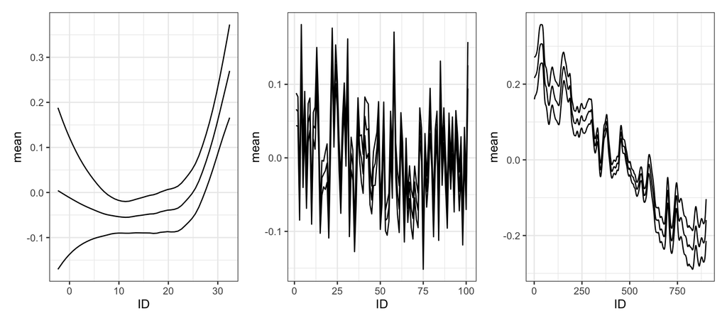

```r
ggplot(data = mod5$summary.random$temp_id) +
  geom_line(aes(x=ID, y=mean)) +
  geom_line(aes(x=ID, y=`0.025quant`)) +
  geom_line(aes(x=ID, y=`0.975quant`)) + theme_bw()|

ggplot(data = mod5$summary.random$space_id[1:101,]) +
  geom_line(aes(x=ID, y=mean)) +
  geom_line(aes(x=ID, y=`0.025quant`)) +
  geom_line(aes(x=ID, y=`0.975quant`)) + theme_bw()|

ggplot(data = mod5$summary.random$datid) +
  geom_line(aes(x=ID, y=mean)) +
  geom_line(aes(x=ID, y=`0.025quant`)) +
  geom_line(aes(x=ID, y=`0.975quant`)) + theme_bw()
```

```r
N_plot <- 200
# x is temperature
# y is PM10

proj = inla.mesh.projector(mesh, xlim=c(0,cut_var), ylim=c(0,cut_var), dims=c(N_plot, N_plot))
field.proj = inla.mesh.project(proj, mod5$summary.random[['field']][['mean']])
# image.plot(list(x = proj$x, y=proj$y, z = exp(field.proj)), col = plasma(101))

field.proj_sd = inla.mesh.project(proj, mod5$summary.random[['field']][['sd']])
# image.plot(list(x = proj$x, y=proj$y, z = field.proj_sd), col = plasma(101))

summary(mod5)
```

```
##
## Call:
##    c("inla.core(formula = formula, family = family, contrasts = contrasts,
##    ", " data = data, quantiles = quantiles, E = E, offset = offset, ", "
##    scale = scale, weights = weights, Ntrials = Ntrials, strata = strata,
##    ", " lp.scale = lp.scale, link.covariates = link.covariates, verbose =
##    verbose, ", " lincomb = lincomb, selection = selection, control.compute
##    = control.compute, ", " control.predictor = control.predictor,
##    control.family = control.family, ", " control.inla = control.inla,
##    control.fixed = control.fixed, ", " control.mode = control.mode,
##    control.expert = control.expert, ", " control.hazard = control.hazard,
##    control.lincomb = control.lincomb, ", " control.update =
##    control.update, control.lp.scale = control.lp.scale, ", "
##    control.pardiso = control.pardiso, only.hyperparam = only.hyperparam,
##    ", " inla.call = inla.call, inla.arg = inla.arg, num.threads =
##    num.threads, ", " blas.num.threads = blas.num.threads, keep = keep,
##    working.directory = working.directory, ", " silent = silent, inla.mode
##    = inla.mode, safe = FALSE, debug = debug, ", " .parent.frame =
##    .parent.frame)")
## Time used:
##     Pre = 9.59, Running = 65.2, Post = 1.97, Total = 76.7
## Fixed effects:
##                   mean    sd 0.025quant 0.5quant 0.975quant   mode kld
## (Intercept)     -0.195 0.024     -0.242   -0.195     -0.148 -0.195   0
## as.factor(hol)1 -0.019 0.008     -0.034   -0.019     -0.004 -0.019   0
## year_cont        0.076 0.010      0.057    0.076      0.095  0.076   0
## pm10_lag0_3      0.002 0.001      0.000    0.002      0.004  0.002   0
##
## Random effects:
##   Name     Model
##     datid RW2 model
##    space_id BYM2 model
##    temp_id RW2 model
##    field SPDE2 model
##
## Model hyperparameters:
##                           mean      sd 0.025quant 0.5quant 0.975quant    mode
## Precision for datid      0.312   0.055      0.219    0.307      0.433   0.297
## Precision for space_id 234.750  34.075    173.960  232.641    307.956 228.905
## Phi for space_id         0.087   0.080      0.005    0.062      0.306   0.015
## Precision for temp_id  527.566 297.733    162.846  459.522   1294.199 348.497
## Range for field         90.559  87.873     18.055   64.887    323.978  38.113
## Stdev for field          0.165   0.145      0.037    0.123      0.553   0.076
##
## Marginal log-Likelihood:  -263256.54
##  is computed
## Posterior summaries for the linear predictor and the fitted values are computed
## (Posterior marginals needs also 'control.compute=list(return.marginals.predictor=TRUE)')
```

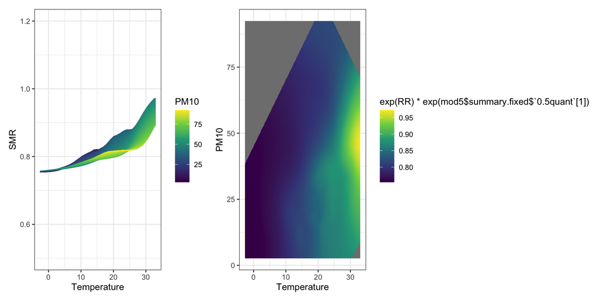

```r
Xmat <- as.data.frame(field.proj)
Xmat$Temperature <- seq(from = min(dat$temperature_lag0_3), to = max(dat$temperature_lag0_3), length.out = N_plot)

data_long <- gather(Xmat, PM10id, RR, V1:V200, factor_key=TRUE)
dat_merge <- data.frame(PM10id = paste0("V", 1:N_plot),
                        PM10 = seq(from = min(dat$pm10_lag0_3), to = max(dat$pm10_lag0_3), length.out = N_plot))

data_long <- left_join(data_long, dat_merge, by = c("PM10id" = "PM10id"))


ggplot() + geom_line(data = data_long,
                     aes(x = Temperature, y = exp(RR)*exp(mod5$summary.fixed$`0.5quant`[1]), group = PM10, col = PM10)) +
  scale_color_viridis_c() +
  scale_fill_viridis_c() +
  ylab("SMR") +
    theme_bw() +
  ylim(c(0.5, 1.2)) -> p1

ggplot() + geom_tile(data = data_long, aes(x = Temperature, y = PM10, fill = exp(RR)*exp(mod5$summary.fixed$`0.5quant`[1]))) + theme_bw() +
  scale_fill_viridis_c() -> p3


P4 <- p1|p3
P4
```

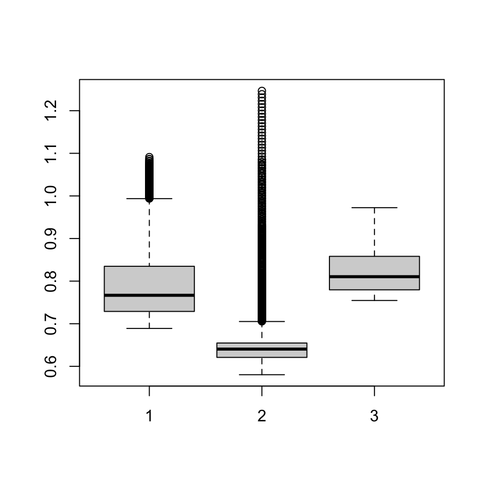

```r
boxplot(boxcomp_regint, boxcomp_linint, exp(data_long$RR)*exp(mod5$summary.fixed$`0.5quant`[1]))
```